# Insertion Sort

Algoritma sorting yang ketiga adalah Insertion Sort. Penjelasan algoritma ini dibagi menjadi dua bagian yaitu :

1. Algoritma Insertion Sort
2. Code

Algoritma Insertion Sort Pada algoritma insertion sort, diasumsikan bahwa sebagian data sudah dalam keadaan terurut (pada posisi sebelah kiri dari data list), sehingga data berikutnya akan dibandingkan dengan data yang sudah dalam keadaan terurut ini, dan disisipkan (insertion) pada bagian data yang sudah terurut tersebut. Dengan konsep seperti ini, posisi sebelah kiri dari list data (sebelum ada data baru yang akan disisipkan), selalu dalam keadaan terurut. Berikut algoritma Insertion Sort :

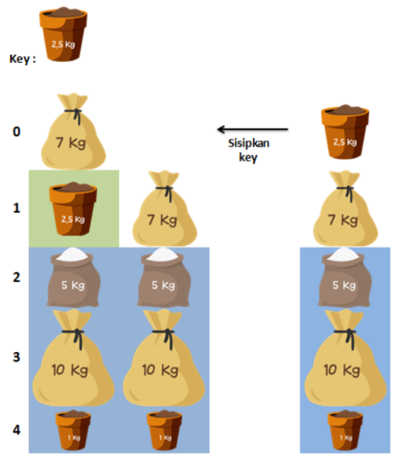

   Gambar 1. Iterasi Pertama Algoritma Insertion Sort Iterasi Kedua. Pada iterasi kedua menjadikan data pada indeks ke-2, yaitu 5, menjadi key. Sehingga pada iterasi kedua ini, berusaha menyispikan key pada kumpulan data terurut sebelumnya, yaitu [2.5, 7], dengan cara membandingkan satu persatu. Karena nilai key lebih kecil dari 7, dan lebih besar dari 2.5, maka key disisipkan diantara kedua nilai tersebut, sehingga data setelah iterasi kedua, menjadi [2.5, 5, 7, 10, 1]. Dapat dilihat bahwa data indeks ke-0, sampai dengan indeks ke-2, sudah dalam keadaan terurut. Ilustrasi ini dapat dilihat pada Gambar 2.

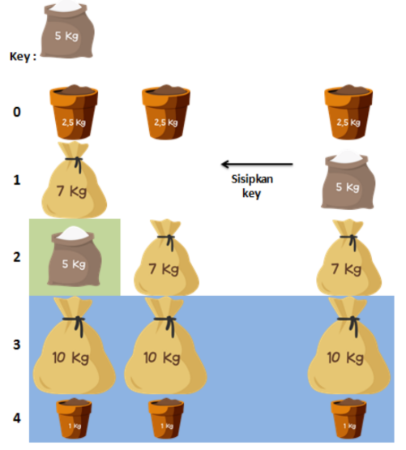

   Gambar 2. Iterasi Kedua Algoritma Insertion Sort Iterasi Ketiga. Key pada iterasi ketiga adalah data pada indeks ke-3, yaitu 10. Tujuan akhir dari iterasi ketiga adalah mencari lokasi yang tepat untuk data 10 diantara data yang sudah urut sebelumnya, yaitu [2.5, 5, 7]. Karena perbandingan pertama yang dilakukan adalah dengan data 7, dan 10 > 7, maka data 10 berada pada tempat yang sama. Ilustrasi iterasi ketiga ini, dapat dilihat pada Gambar 3.

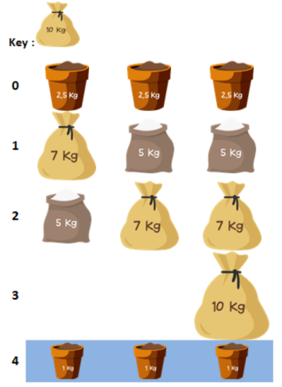

   Gambar 3. Iterasi Ketiga Algoritma Insertion Sort Iterasi Keempat. Key untuk iterasi keempat adalah data pada indeks ke-4, yaitu 1. Pada iterasi keempat ini bertujuan untuk menyisipkan data 1 pada data yang sudah dalam keaadan urut sebelumnya, yaitu [2.5, 5, 7, 10]. Perbandingan dilakukan sebanyak empat kali untuk mencari posisi yang tepat untuk data 1 ini. Sehingga data 1 harus disisipkan, sebelum data 2.5. Ilustrasi ini dapat dilihat pada Gambar 4.

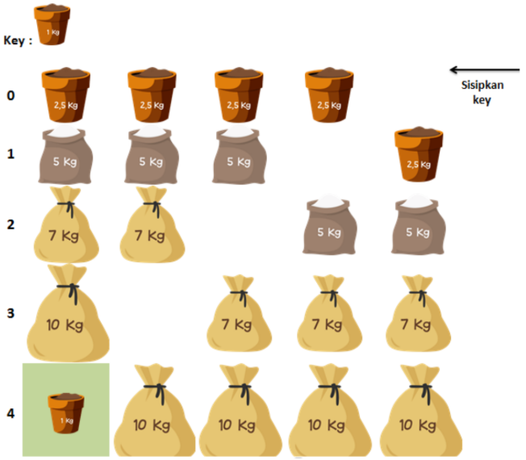

   Gambar 4. Iterasi Keempat Algoritma Insertion Sort Akhir dari iterasi keempat ini adalah data sudah dalam keaadan terurut, seperti yang ditunjukkan pada Gambar 5.

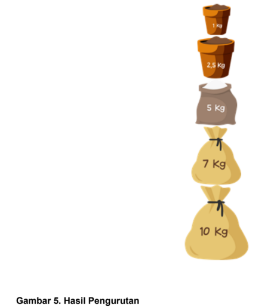

```python
def insertionSort(listData):

    for i in range(1,len(listData)):
        print(listData)
        key=listData[i]
        ind=i
        while (ind>0 and listData[ind-1]>key):
            listData[ind]=listData[ind-1]
            ind=ind-1
            print('inner=',listData)
            listData[ind]=key
            print('sortedData=',listData)

b=[10,2,5,8,1,20,2,2,4]
b=[3, 1, 9, 12, 2, 15, 19]
insertionSort(b)
```

```
[3, 1, 9, 12, 2, 15, 19]
inner= [3, 3, 9, 12, 2, 15, 19]
sortedData= [1, 3, 9, 12, 2, 15, 19]
[1, 3, 9, 12, 2, 15, 19]
[1, 3, 9, 12, 2, 15, 19]
[1, 3, 9, 12, 2, 15, 19]
inner= [1, 3, 9, 12, 12, 15, 19]
sortedData= [1, 3, 9, 2, 12, 15, 19]
inner= [1, 3, 9, 9, 12, 15, 19]
sortedData= [1, 3, 2, 9, 12, 15, 19]
inner= [1, 3, 3, 9, 12, 15, 19]
sortedData= [1, 2, 3, 9, 12, 15, 19]
[1, 2, 3, 9, 12, 15, 19]
[1, 2, 3, 9, 12, 15, 19]
```

```python
lst=[10,2,5,8,1,20,2,2,4]

for i in range(1,len(lst)):
    nilaiawal=lst[i]
    hole= i
    while lst[hole-1] > nilaiawal and hole > 0 :
        lst[hole] = lst[hole-1]
        hole=hole-1
        lst[hole] = nilaiawal
    print(lst)
```

```
[2, 10, 5, 8, 1, 20, 2, 2, 4]
[2, 5, 10, 8, 1, 20, 2, 2, 4]
[2, 5, 8, 10, 1, 20, 2, 2, 4]
[1, 2, 5, 8, 10, 20, 2, 2, 4]
[1, 2, 5, 8, 10, 20, 2, 2, 4]
[1, 2, 2, 5, 8, 10, 20, 2, 4]
[1, 2, 2, 2, 5, 8, 10, 20, 4]
[1, 2, 2, 2, 4, 5, 8, 10, 20]
```

```python
def insertion_sort(arr):
    for i in range(1, len(arr)):
        key = arr[i]
        j = i - 1

        while j >= 0 and arr[j] > key:
            arr[j+1] = arr[j]
            j -= 1

        arr[j+1] = key
    return arr

data = [5, 2, 9, 1, 7]
print(insertion_sort(data))
```

[output not shown]